# OOPs Analysis

# Search Strategy and Aggregation

The surveys went through a compilation process, where information on household’s OOPs, hospitalizations, non-health consumption, and characteristics such as the household size, marital status and age of the householdhead, and rural or urban locations were collected. When available, we used aggregate consumption files provided by the surveys to estimate consumption measures. When no aggregate consumption file was available, consumption was computed by the benchmark methods detailed in Deaton and Zaidi (2002). When calculating consumption a broad definition was used, which includes food consumption, non-food consumption, imputed rent, and the cost of the use of consumer durables.

OOPs were calculated for each household on the health and consumption module. In the health module the OOPs were calculated as the sum of all health expenditures declared by each individual household member, and then adjusted to represent a 1-year recall period. The OOPs in the consumption module were calculated in similar fashion, by adding all health expenditures declared by the household in the module, and then adjusting them to a 1-year recall period.

Despite a similar process to calculate OOPs in both modules, it is relevant to notice that each module captures OOPs in very different ways. The health module is not purposedly built to measure consumption, and OOPs are added as an extra, this results in three different styles in which OOPs can be captured in the health module (Exhibited in Figure 1). The first style is health care utilization, where each household member is asked whether or not they have used a specific health service in a determined amount of time. If they answer yes, a sequence of questions about the specific service ensues, including OOPs. On the other hand, if they answer no the sequence is skipped. The second style is episodic, where each household member is asked if they have suffered an illness or injury in the recent past. Similarly, if they answer yes a sequence of questions continues including OOPs. The third and least popular is the direct style, where each household member reports their expenses for a list of different health services and items. The direct style is not attached to the utilization of health services, or an episode of illness, every household member has to answer. The consumption module on the other hand is build to measure consumption, each household reports their expenses for a specified list of products, and services without a possibility of skipping questions.

| Survey | Survey Name | LSMS Status | Items Health Module | Items Consumption Module | Avg. Recall Health Module | Avg. Recall Consumption Module | Observations | Mean Non-Health Consumption | Mean OOPs Health Module | Mean OOPs Consumption Module |
| --- | --- | --- | --- | --- | --- | --- | --- | --- | --- | --- |
| Bulgaria_2003 | Multitopic Household Survey 2003 | official | 7 | 2 | 28.0 | 28.0 | 3023 | 5236* | 293.2* | 277* |
| Bulgaria_2007 | Multitopic Household Survey 2007 | official | 7 | 2 | 13.0 | 13.0 | 4295 | 7836.7 | 1091.1 | 464.9 |
| Ghana_1988 | Living Standards Survey I 1987-1988 | official | 4 | 2 | 4.0 | 52.0 | 2850 | 783.8 | 87.6 | 14.3 |
| Ghana_1989 | Living Standards Survey II 1988-1989 | official | 4 | 2 | 4.0 | 52.0 | 1011 | 1172.1* | 118.6* | 22.1* |
| Ghana_1991 | Living Standards Survey III 1991 | official | 8 | 8 | 7.0 | 35.8 | 4517 | 3077.3 | 176.8 | 100.5 |
| Ghana_2006 | Living Standards Survey V 2005-2006 | continuation | 5 | 22 | 2.0 | 43.1 | 2999 | 23465.1 | 1912.8 | 686.1 |
| Ghana_2013 | Living Standards Survey VI 2012-2013 | continuation | 14 | 22 | 2.0 | 43.1 | 16744 | 12498.6 | 584.8 | 120.9 |
| Ghana_2017 | Living Standards Survey VII 2017 | continuation | 14 | 32 | 2.0 | 44.7 | 13899 | 14538.9 | 10.9 | 110.5 |
| Iraq_2007 | Household Socio-Economic Survey 2006-2007 | official | 5 | 44 | 4.0 | 21.9 | 17441 | 1861.3 | 267.8 | 46 |
| Nigeria_2011 | General Household Survey, Panel 2010-2011, Wave 1 | official | 5 | 1 | 7.2 | 26.0 | 1936 | 6900.6 | 105.9 | 52.4 |
| Nigeria_2013 | General Household Survey, Panel 2012-2013, Wave 2 | official | 1 | 5 | 7.2 | 26.0 | 1474 | 7831.7 | 196.8 | 60.1 |
| Nigeria_2016 | General Household Survey, Panel 2015-2016, Wave 3 | official | 5 | 1 | 7.2 | 26.0 | 4537 | 2704.7 | 607.2 | 89.7 |
| Uganda_2005 | NA | NA | 2 | 5 | 4.0 | 4.0 | 3072 | 45787.1 | 174.6 | 173.7 |
| Uganda_2009 | National Panel Survey 2009 | official | 1 | 5 | 4.0 | 4.0 | 2701 | 22013.2 | 250.2 | 264.1 |
| Uganda_2011 | National Panel Survey 2010-2011 | official | 1 | 5 | 4.0 | 4.0 | 2600 | 22654.4 | 258.8 | 260.3 |
| Uganda_2012 | National Panel Survey 2011-2012 | official | 1 | 5 | 4.0 | 4.0 | 2800 | 23565.9 | 244.1 | 262.9 |
| Uganda_2014 | National Panel Survey 2013-2014 | official | 1 | 5 | 4.0 | 4.0 | 1648 | 28442.8 | 349.4 | 364.3 |

Note:  
Consumption averages are expressed in 2011 USD PPP. The surveys of Ghana_2006 through Ghana_2017 do not belong to the LSMS program, but they continue the work of previous LSMS surveys in Ghana. * sampling weights were not available for calculation

| survey | Survey Name | Items Health Module | Avg. Recall Health Module | Percent_episodic | Percent_hosp | Percent_utilization | Percent_direct | Percent_trad | Observations | Mean Non-Health Consumption | Mean OOPs Health Module |
| --- | --- | --- | --- | --- | --- | --- | --- | --- | --- | --- | --- |
| Ethiopia_2016 | Socioeconomic Survey 2015-2016, Wave 3 | 1 | 28.000000 | 100.0 | 0.0 | 0.0 | 0.0 | 0.0 | 4881 | 5023.2 | 84.9 |
| Ghana_1988 | Living Standards Survey I 1987-1988 | 4 | 4.000000 | 75.0 | 25.0 | 0.0 | 0.0 | 0.0 | 2866 | 783.8 | 88.3 |
| Ghana_1989 | Living Standards Survey II 1988-1989 | 4 | 4.000000 | 75.0 | 25.0 | 0.0 | 0.0 | 0.0 | 1011 | 1172.1* | 118.6* |
| Ghana_1991 | Living Standards Survey III 1991 | 8 | 7.000000 | 37.5 | 12.5 | 50.0 | 0.0 | 0.0 | 4517 | 3077.3 | 176.8 |
| Ghana_2006 | Living Standards Survey V 2005-2006 | 5 | 2.000000 | 42.9 | 14.3 | 42.9 | 0.0 | 0.0 | 2999 | 23465.1 | 1912.8 |
| Ghana_2013 | Living Standards Survey VI 2012-2013 | 14 | 2.000000 | 58.3 | 8.3 | 25.0 | 8.3 | 0.0 | 16744 | 12498.6 | 584.8 |
| Ghana_2017 | Living Standards Survey VII 2017 | 14 | 2.000000 | 53.8 | 7.7 | 30.8 | 7.7 | 0.0 | 13899 | 14538.9 | 10.9 |
| Iraq_2007 | Household Socio-Economic Survey 2006-2007 | 5 | 4.000000 | 100.0 | 0.0 | 0.0 | 0.0 | 0.0 | 17441 | 1861.3 | 267.8 |
| Malawi_2005 | Second Integrated Household Survey 2004-2005 | 5 | 13.600000 | 0.0 | 20.0 | 0.0 | 60.0 | 20.0 | 11280 | 1231.4 | 16.4 |
| Malawi_2010 | Third Integrated Household Panel Survey 2010-2013 | 9 | 25.333334 | 33.3 | 11.1 | 0.0 | 33.3 | 22.2 | 12267 | 3111 | 44.3 |
| Malawi_2013 | Third Integrated Household Panel Survey 2010-2013 | 9 | 25.333334 | 22.2 | 11.1 | 0.0 | 33.3 | 33.3 | 3078 | 9188.2 | 103.8 |
| Malawi_2017 | Fourth Integrated Household Survey 2016-2017 | 9 | 36.000000 | 33.3 | 11.1 | 0.0 | 33.3 | 22.2 | 12447 | 10272 | 197 |
| Tanzania_2009 | National Panel Survey 2008-2009, Wave 1 | 5 | 23.200001 | 20.0 | 20.0 | 0.0 | 40.0 | 20.0 | 3265 | 4231.2 | 186.2 |
| Tanzania_2011 | National Panel Survey 2010-2011, Wave 2 | 6 | 20.000000 | 16.7 | 16.7 | 0.0 | 50.0 | 16.7 | 3221 | 5092.8 | 197.7 |
| Tanzania_2013 | National Panel Survey 2012-2013, Wave 3 | 6 | 20.000000 | 16.7 | 16.7 | 0.0 | 50.0 | 16.7 | 4883 | 6395.7 | 267.8 |
| Tanzania_2015 | National Panel Survey 2014-2015, Wave 4 | 6 | 20.000000 | 16.7 | 16.7 | 0.0 | 50.0 | 16.7 | 3343 | 6807 | 268.4 |
| Nigeria_2011 | General Household Survey, Panel 2010-2011, Wave 1 | 5 | 7.200000 | 40.0 | 20.0 | 0.0 | 40.0 | 0.0 | 1936 | 6900.6 | 105.9 |
| Nigeria_2013 | General Household Survey, Panel 2012-2013, Wave 2 | 1 | 7.200000 | 60.0 | 20.0 | 0.0 | 20.0 | 0.0 | 1474 | 7831.7 | 196.8 |
| Nigeria_2016 | General Household Survey, Panel 2015-2016, Wave 3 | 5 | 7.200000 | 40.0 | 20.0 | 0.0 | 40.0 | 0.0 | 4537 | 2704.7 | 607.2 |
| Uganda_2005 | NA | NA | NA | 100.0 | 0.0 | 0.0 | 0.0 | 0.0 | 3072 | 45787.1 | 174.6 |
| Uganda_2009 | National Panel Survey 2009 | 1 | 4.000000 | 100.0 | 0.0 | 0.0 | 0.0 | 0.0 | 2880 | 22013.2 | 245.4 |
| Uganda_2011 | National Panel Survey 2010-2011 | 1 | 4.000000 | 100.0 | 0.0 | 0.0 | 0.0 | 0.0 | 2614 | 22654.4 | 259.3 |
| Uganda_2012 | National Panel Survey 2011-2012 | 1 | 4.000000 | 100.0 | 0.0 | 0.0 | 0.0 | 0.0 | 2811 | 23565.9 | 244 |
| Uganda_2014 | National Panel Survey 2013-2014 | 1 | 4.000000 | 100.0 | 0.0 | 0.0 | 0.0 | 0.0 | 1650 | 28442.8 | 349.4 |
| Albania_2002 | Living Standards Measurement Survey 2002 (Wave 1 Panel) | 30 | 20.000000 | 0.0 | 16.7 | 80.0 | 3.3 | 0.0 | 3598 | 8986.9* | 617.3* |
| Albania_2005 | Living Standards Measurement Survey 2005 | 36 | 17.333334 | 0.0 | 13.9 | 69.4 | 2.8 | 13.9 | 3527 | 92079.4* | 4471.7* |
| Albania_2008 | NA | NA | NA | 0.0 | 13.9 | 69.4 | 2.8 | 13.9 | NA | NA | NA |
| Bosnia_2001 | Living Standards Measurement Survey 2001 (Wave 1 Panel) | 26 | 6.153846 | 0.0 | 11.5 | 88.5 | 0.0 | 0.0 | 5357 | 9596.7* | 743.9* |
| Bosnia_2004 | Living Standards Measurement Survey 2004 (Wave 4 Panel) | 8 | 60.000000 | 0.0 | 12.5 | 87.5 | 0.0 | 0.0 | 3031 | 8580.9* | 320.8* |
| Bulgaria_2003 | Multitopic Household Survey 2003 | 7 | 28.000000 | 0.0 | 0.0 | 0.0 | 100.0 | 0.0 | 3023 | 5236* | 293.2* |
| Bulgaria_2007 | Multitopic Household Survey 2007 | 7 | 13.000000 | 0.0 | 0.0 | 0.0 | 100.0 | 0.0 | 4295 | 7836.7 | 1091.1 |

Note:  
Consumption averages are expressed in 2011 USD PPP. The surveys of Ghana_2006 through Ghana_2017 do not belong to the LSMS program, but they continue the work of previous LSMS surveys in Ghana. * sampling weights were not available for calculation

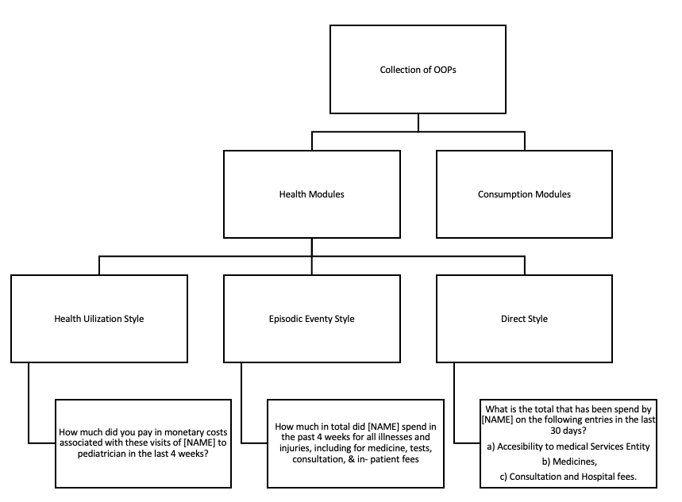

Figure 1: OOP collection styles

# Survey instruments to measure OOPs

Examining Table 2 it is apparent that no survey/module pair covers all the health expenditure subcategories included in the COICOP standard. The most covered category is medicines, vaccines and other pharmaceutical preparations driven by instruments dedicated to the purchase of prescripbed medicines (in health modules), and medicine in general (in the consumption module). The outpatient long-term care and inpatient long-term care sub-categories were not part of any survey. These categories are dedicated to rehabilitation and prevent deterioration of a condition in the oupatient case, and convalesent homes or hospitals, or nursing care facilities for the inpatient case.

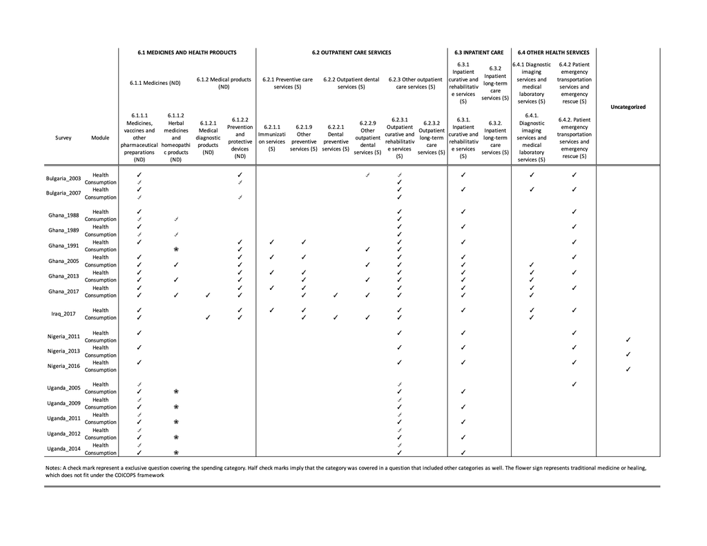

Table 2: COICOPS classification of healthcare expenditures

# Household OOPs in the health and consumption module

The 17 surveys in our sample have two OOP estimates for each household from the health and consumption module. The availability of such data makes it possible to compare how similar the two estimates are on each survey. In Figure 2 a heatmap is exhibited for each survey, where OOPs in the health module are on the y-axis, and OOPs in the consumption module are on the x-axis. The color of the hexagons represents the concentration of observations around the area, with more intense tones representing a higher concentration. Each panel also includes a dashed 45-degree line, where the values of the OOPs in the health module and consumption module are equal. A concentration of observations above (below) the dashed line represents higher (lower) reporting in the health module than the consumption module.

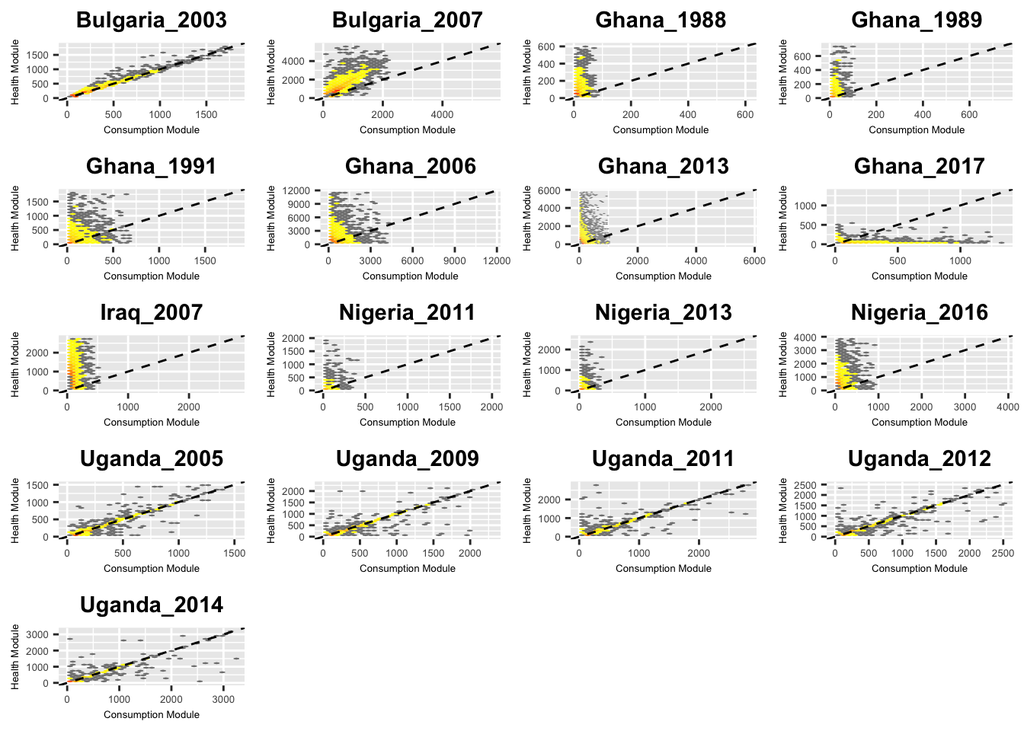

## Regression Analysis

Regression Models: OOPs in health module (DV), and OOPs in consumption module

Simple Model

With household characteristics

With household head characteristics

With hospitalization

Predictors

Estimates

CI

Estimates

CI

Estimates

CI

Estimates

CI

(Intercept)

106.85 ***

84.61 – 129.10

-13.62

-38.65 – 11.42

-126.45 ***

-176.84 – -76.06

-382.92 ***

-451.61 – -314.23

Consumption

0.67 ***

0.59 – 0.75

0.66 ***

0.58 – 0.74

0.66 ***

0.58 – 0.74

0.48 ***

0.38 – 0.59

urbanTRUE

85.05 ***

67.72 – 102.38

107.78 ***

84.97 – 130.58

128.41 ***

102.02 – 154.79

hhsize

24.30 ***

21.42 – 27.19

25.02 ***

20.91 – 29.13

23.67 ***

18.65 – 28.68

hhead_age

1.34 ***

0.69 – 1.99

1.55 ***

0.77 – 2.34

episodic_hospTRUE

1525.52 ***

1362.35 – 1688.69

Observations

83252

82887

61480

48982

R<sup>2</sup> / R<sup>2</sup> adjusted

0.142 / 0.142

0.146 / 0.145

0.156 / 0.156

0.164 / 0.163

- p<0.05 ** p<0.01 *** p<0.001

Regression Models: OOPs in health module (DV), and OOPs in consumption module (No Fixed Effects)

Simple Model

With household characteristics

With household head characteristics

With hosp

Predictors

Estimates

CI

Estimates

CI

Estimates

CI

Estimates

CI

(Intercept)

127.12 ***

109.40 – 144.84

-36.85 **

-59.41 – -14.29

-157.73 ***

-201.02 – -114.44

-534.25 ***

-608.16 – -460.35

Consumption

0.78 ***

0.70 – 0.85

0.77 ***

0.69 – 0.85

0.78 ***

0.70 – 0.86

0.70 ***

0.59 – 0.81

diff_nitems

-1.00 ***

-1.42 – -0.58

0.81 ***

0.34 – 1.27

15.05 ***

13.40 – 16.69

20.21 ***

17.60 – 22.83

diff_recall

-3.46 ***

-3.92 – -3.00

-4.25 ***

-4.73 – -3.78

-9.74 ***

-10.46 – -9.02

-19.66 ***

-21.53 – -17.78

urbanTRUE

85.54 ***

68.60 – 102.48

101.31 ***

78.57 – 124.04

123.62 ***

96.69 – 150.54

hhsize

24.77 ***

22.02 – 27.51

26.22 ***

22.30 – 30.15

25.69 ***

20.89 – 30.48

hhead_age

1.26 ***

0.61 – 1.90

1.53 ***

0.74 – 2.33

episodic_hospTRUE

1579.78 ***

1413.81 – 1745.75

Observations

83252

82887

61480

48982

R<sup>2</sup> / R<sup>2</sup> adjusted

0.088 / 0.088

0.093 / 0.092

0.104 / 0.103

0.108 / 0.108

- p<0.05 ** p<0.01 *** p<0.001

Regression Models: Subset- Positive OOPs in Health Module and Consumption Module

H>0:Simple Model

H>0:With household characteristics

H>0:With household head characteristics

H>0:With hospitalization

C>0:Simple Model

C>0:With household characteristics

C>0:With household head characteristics

C>0:With hospitalization

Predictors

Estimates

CI

Estimates

CI

Estimates

CI

Estimates

CI

Estimates

CI

Estimates

CI

Estimates

CI

Estimates

CI

(Intercept)

100.22 ***

73.14 – 127.30

-88.35 ***

-123.52 – -53.18

-263.79 ***

-347.29 – -180.28

-544.41 ***

-652.21 – -436.61

118.87 ***

93.59 – 144.16

-12.46

-42.22 – 17.29

-159.61 ***

-233.71 – -85.50

-455.16 ***

-553.57 – -356.75

Consumption

0.73 ***

0.64 – 0.81

0.71 ***

0.62 – 0.80

0.70 ***

0.61 – 0.79

0.55 ***

0.42 – 0.68

0.66 ***

0.58 – 0.75

0.65 ***

0.57 – 0.73

0.65 ***

0.56 – 0.73

0.48 ***

0.37 – 0.59

urbanTRUE

176.77 ***

145.83 – 207.72

224.93 ***

186.28 – 263.59

264.75 ***

219.30 – 310.20

93.51 ***

69.83 – 117.19

133.58 ***

99.01 – 168.16

161.32 ***

120.96 – 201.68

hhsize

26.07 ***

21.39 – 30.75

25.02 ***

18.84 – 31.20

22.86 ***

15.16 – 30.55

25.75 ***

22.17 – 29.33

29.67 ***

23.93 – 35.42

28.27 ***

21.19 – 35.36

hhead_age

2.18 ***

1.10 – 3.27

2.44 ***

1.11 – 3.77

1.46 **

0.48 – 2.44

1.93 **

0.74 – 3.13

episodic_hospTRUE

1453.15 ***

1287.84 – 1618.46

1524.89 ***

1342.46 – 1707.32

Observations

46125

45879

36130

28199

55913

55660

37252

29145

R<sup>2</sup> / R<sup>2</sup> adjusted

0.168 / 0.168

0.172 / 0.172

0.177 / 0.177

0.180 / 0.179

0.154 / 0.153

0.157 / 0.157

0.167 / 0.167

0.169 / 0.169

- p<0.05 ** p<0.01 *** p<0.001

Regression Models: Positive OOPs in Health Module and Consumption Module

H>0:Simple Model

H>0:With household characteristics

H>0:With household head characteristics

H>0:With hosp

C>0:Simple Model

C>0:With household characteristics

C>0:With household head characteristics

C>0:With hosp

Predictors

Estimates

CI

Estimates

CI

Estimates

CI

Estimates

CI

Estimates

CI

Estimates

CI

Estimates

CI

Estimates

CI

(Intercept)

177.93 ***

150.53 – 205.33

-19.74

-57.13 – 17.64

-161.04 ***

-236.56 – -85.52

-818.07 ***

-938.49 – -697.64

117.48 ***

92.65 – 142.31

-27.67

-58.73 – 3.38

-178.96 ***

-245.53 – -112.40

-484.39 ***

-590.55 – -378.23

Consumption

0.81 ***

0.72 – 0.90

0.81 ***

0.72 – 0.89

0.83 ***

0.74 – 0.92

0.78 ***

0.65 – 0.92

0.75 ***

0.67 – 0.83

0.75 ***

0.67 – 0.83

0.73 ***

0.65 – 0.82

0.62 ***

0.50 – 0.73

diff_nitems

-9.45 ***

-10.24 – -8.67

-7.20 ***

-8.04 – -6.37

23.11 ***

20.37 – 25.86

39.28 ***

34.76 – 43.79

-2.48 ***

-2.99 – -1.97

-0.80 **

-1.37 – -0.22

5.07 ***

2.22 – 7.92

5.74 *

1.34 – 10.15

diff_recall

-6.71 ***

-7.50 – -5.92

-7.23 ***

-8.02 – -6.45

-19.65 ***

-20.92 – -18.38

-38.66 ***

-41.62 – -35.69

-5.24 ***

-5.90 – -4.58

-5.79 ***

-6.46 – -5.13

-9.56 ***

-10.58 – -8.54

-16.66 ***

-19.14 – -14.18

urbanTRUE

178.99 ***

149.25 – 208.73

208.06 ***

169.49 – 246.64

278.07 ***

231.05 – 325.09

75.26 ***

52.67 – 97.85

135.45 ***

101.05 – 169.86

158.90 ***

117.61 – 200.19

hhsize

24.40 ***

19.88 – 28.92

25.51 ***

19.59 – 31.43

16.57 ***

9.02 – 24.13

21.62 ***

18.15 – 25.08

28.20 ***

22.73 – 33.67

27.78 ***

20.91 – 34.65

hhead_age

0.94

-0.13 – 2.01

2.16 **

0.82 – 3.51

1.52 **

0.55 – 2.49

1.78 **

0.57 – 3.00

episodic_hospTRUE

1491.37 ***

1321.03 – 1661.71

1600.26 ***

1414.28 – 1786.23

Observations

46125

45879

36130

28199

55913

55660

37252

29145

R<sup>2</sup> / R<sup>2</sup> adjusted

0.094 / 0.094

0.099 / 0.099

0.113 / 0.113

0.116 / 0.116

0.096 / 0.096

0.099 / 0.099

0.107 / 0.107

0.107 / 0.106

- p<0.05 ** p<0.01 *** p<0.001

# Average OOPs

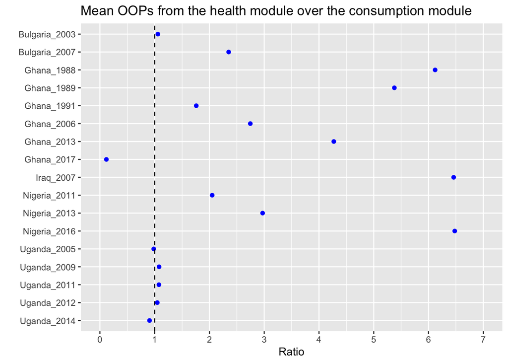

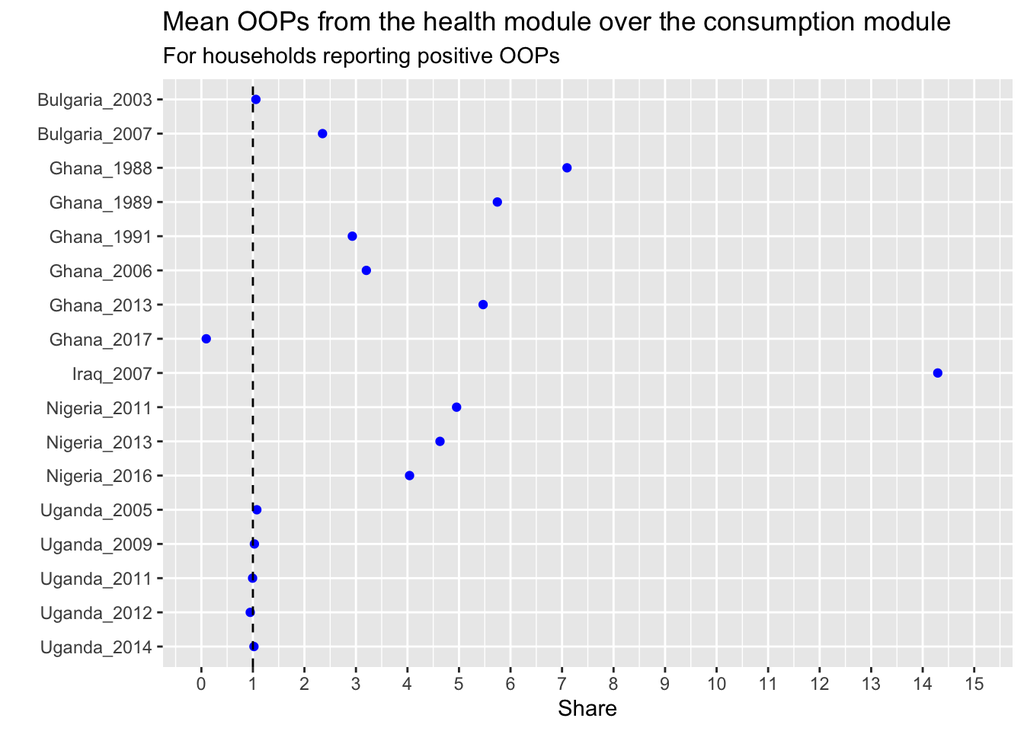

On average 26.2% and 34.3% of the households report zero OOPs in the consumption and health module respectively.

# Zero OOPs

Households reporting zero OOPs is a common characteristic of health care data. Many households do not spend on health care because they had no health shocks, or they could not afford treatment. On average 26.2% and 34.3% of the households report zero OOPs in the consumption and health module respectively.

As the percentage of zero OOPs differs between modules in all surveys, it will be interesting to check how concordant the answers between modules are. Across all surveys, 17.5% of households report zero OOPs in both modules, and 57.1% report positive OOPs in both. In total 74.6% of households report concordant OOPs between modules (both positive, or both negative), leaving 25.4% of households that differ on their answers between modules, which is problematic from a measuring perspective.

| Survey | Both Zero | Consumption>0, Health>0 | Consumption=0, Health=0 | Both Positive | Concordance Rate | Non-Concordance Rate |
| --- | --- | --- | --- | --- | --- | --- |
| Bulgaria_2003 | 8.1 | 0.0 | 0.0 | 91.9 | 100.0 | 0.0 |
| Bulgaria_2007 | 8.0 | 0.8 | 0.5 | 90.7 | 98.7 | 1.3 |
| Ghana_1988 | 2.5 | 14.2 | 1.8 | 81.2 | 83.7 | 16.3 |
| Ghana_1989 | 0.0 | 13.6 | 0.0 | 86.4 | 86.4 | 13.6 |
| Ghana_1991 | 9.9 | 39.1 | 5.2 | 45.8 | 55.7 | 44.3 |
| Ghana_2006 | 0.0 | 13.5 | 0.0 | 86.5 | 86.5 | 13.5 |
| Ghana_2013 | 28.2 | 23.2 | 15.4 | 33.3 | 61.5 | 38.5 |
| Ghana_2017 | 37.5 | 14.4 | 26.0 | 21.8 | 59.3 | 40.7 |
| Iraq_2007 | 14.4 | 48.8 | 1.7 | 35.0 | 49.4 | 50.6 |
| Nigeria_2011 | 16.3 | 28.2 | 4.0 | 12.1 | 28.4 | 71.6 |
| Nigeria_2013 | 7.7 | 16.1 | 5.1 | 24.4 | 32.1 | 67.9 |
| Nigeria_2016 | 0.0 | 0.0 | 36.3 | 63.4 | 63.4 | 36.6 |
| Uganda_2005 | 28.0 | 5.6 | 0.9 | 65.4 | 93.4 | 6.6 |
| Uganda_2009 | 24.3 | 2.6 | 1.3 | 68.2 | 92.5 | 7.5 |
| Uganda_2011 | 35.0 | 1.9 | 3.7 | 58.4 | 93.4 | 6.6 |
| Uganda_2012 | 38.9 | 2.6 | 3.5 | 54.6 | 93.5 | 6.5 |
| Uganda_2014 | 38.1 | 7.1 | 3.0 | 51.8 | 89.9 | 10.1 |

Note:  
The columns represent the percentage of households in each category depending on their reported OOPs in the consumption and health module. The first column is the percentage of households in the survey that reported zero OOPS in both the health module and consumption module. The second column is the percentage of households reporting strictly positive OOPs in the consumption module, and zero OOPs in the health module.

# Mean OOPs by Module and socio-economic status

So far, the mean OOPs from the health module have been higher than those from the consumption module. A possibility is that the socio-economic status of households drives this. Rich or poor households might report more or less OOPs in a specific module. To asses this possibility, quintiles of non-health consumption will be used as a proxy for socio-economic status. Excluding OOPs to asses, socio-economic status is essential as total consumption is not a relevant social marker for households experiencing a health shock, and they had to go through high health care expenditures because of it.

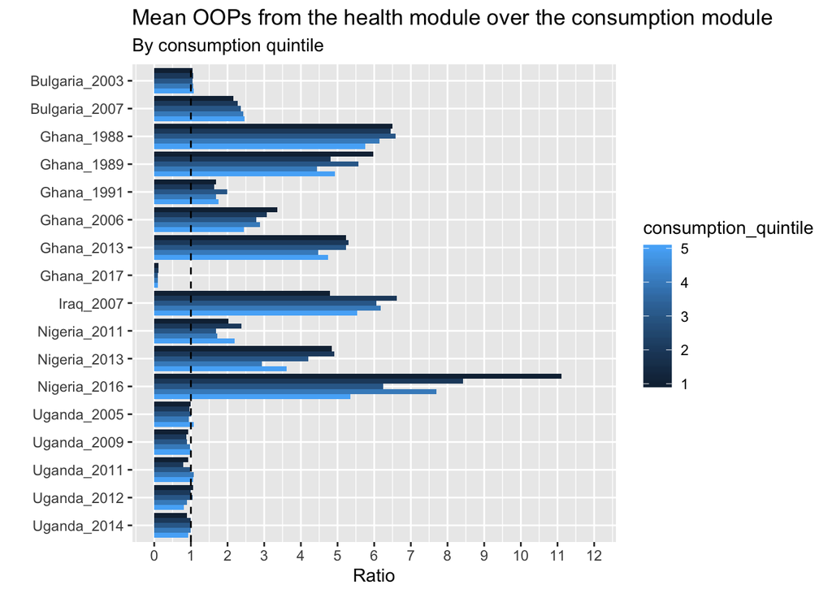

# Catastrophic health expenditures (CHEs)

Popular datasets like the World’s Bank HEFPI, and the World Development Indicators include estimations for the percentage of households incurring into a level of OOPs that is too burdensome to bear. The most popular indicators are Catastrophic health expenditures, which consist on a ratio between the OOPs of a household and its total available resources. What is troubling, is that these popular datasets publish their estimates without stating if the OOPs were coming from the health or consumption module, and without awareness of what are the possible effects of these.

We will use our sample of surveys with OOPs in a consumption and health module, and add these two estimates of OOPs to the non-health consumption of each household to come up with two different estimates of total consumption. Then, we will be able to calculate the most popular indicator of the CHE kind, 10% of total consumption, which is simply an binary variable of whether a household’s OOPs exceed 10% of their total consumption.

Previously, it was evident that mean OOPs were higher for the health module in most surveys. We expect that this should make CHE rates higher using OOPs from the health module, but two factors will determine the magnitude of this difference. The first being if the difference in OOPs between modules is relevant for households with high expenditures. The second being, how significant are OOPs as a share in the total consumption of households.

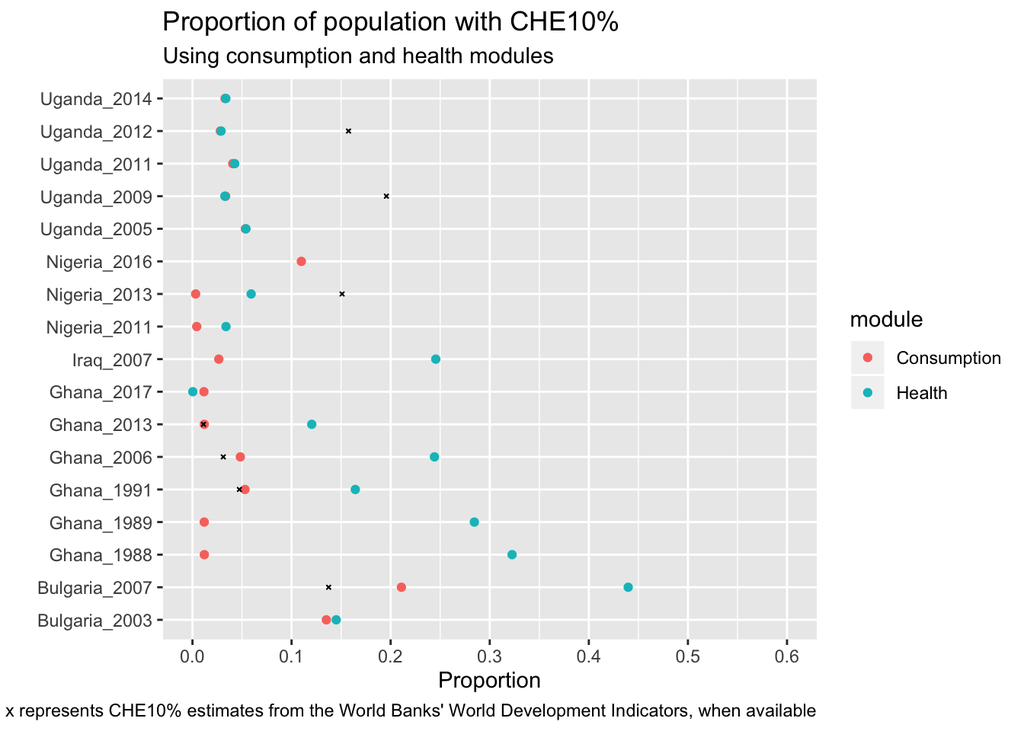

# Hospitalizations

Until now, the analysis has focused on all households without regard of their health care utilization.It is expected that households who have used health services to have higher OOPs, but there is no clarity on whether the health or consumption module is better at capturing these. For 11 out of the 17 surveys in our sample, we have information on whether any household member has declared to be hospitalized, which will we consider as households with hospitalizations through this section.

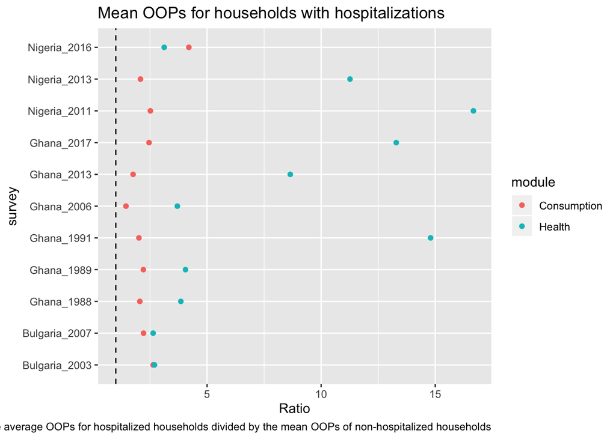

Another important criteria is to check the concordance between the OOPs reported in the health module and consumption module for hospitalized households. A priori, we should expect a very small number of households reporting zero OOPs on either module, given that we know a households member had a delicate condition at least during the last year.

| Survey | Number Hospitalized | Percentage Hospitalized | Recall Period | Both Zero | Both Positive | Consumption>0, Health=0 | Consumption=0, Health>0 | Non-Concordance Rate | Concordance Rate |
| --- | --- | --- | --- | --- | --- | --- | --- | --- | --- |
| Bulgaria_2003 | 559 | 18.5 | 52 | 1.4 | 98.6 | 0.0 | 0.0 | 0.00 | 100.00 |
| Bulgaria_2007 | 743 | 17.3 | 52 | 0.5 | 98.9 | 0.3 | 0.3 | 0.54 | 99.46 |
| Ghana_1988 | 143 | 5.0 | 4 | 0.7 | 98.6 | 0.0 | 0.7 | 0.71 | 99.29 |
| Ghana_1989 | 49 | 4.8 | 4 | 0.0 | 100.0 | 0.0 | 0.0 | 0.00 | 100.00 |
| Ghana_1991 | 104 | 2.3 | 2 | 0.0 | 94.2 | 1.0 | 4.8 | 5.77 | 94.23 |
| Ghana_2006 | 129 | 4.3 | 2 | 0.0 | 96.9 | 3.1 | 0.0 | 3.10 | 96.90 |
| Ghana_2013 | 442 | 2.6 | 2 | 5.2 | 63.8 | 5.2 | 25.8 | 31.00 | 69.00 |
| Ghana_2017 | 109 | 0.8 | 2 | 0.0 | 38.5 | 1.8 | 59.6 | 61.47 | 38.53 |
| Nigeria_2011 | 99 | 5.1 | 52 | 1.0 | 69.7 | 6.1 | 23.2 | 29.29 | 70.71 |
| Nigeria_2013 | 68 | 4.6 | 52 | 0.0 | 73.5 | 0.0 | 26.5 | 26.47 | 73.53 |
| Nigeria_2016 | 503 | 11.1 | 52 | 0.0 | 73.6 | 0.0 | 26.4 | 26.44 | 73.56 |

Note:  
The columns represent the percentage of hospitalized households (at least one member declared an hospitalization). Recall period in weeks.

# Appendix 1 - Comparison of OOPs average vs. WDI

| survey | Mean Health OOPs per capita | Mean Consumption OOPs per capita | Mean OOPs per capita WDI |
| --- | --- | --- | --- |
| Bulgaria_2003 | 107.420793 | 101.500529 | 229.500 |
| Bulgaria_2007 | 384.100278 | 163.673592 | 334.610 |
| Ghana_1988 | 18.185981 | 2.974423 | NA |
| Ghana_1989 | 22.610557 | 4.205654 | NA |
| Ghana_1991 | 39.469201 | 22.434849 | NA |
| Ghana_2006 | 430.467939 | 154.411798 | 79.315 |
| Ghana_2013 | 146.486346 | 30.272239 | 81.322 |
| Ghana_2017 | 2.856169 | 28.916283 | NA |
| Iraq_2007 | 38.776290 | 6.655617 | 103.570 |
| Nigeria_2011 | 15.833783 | 7.830571 | NA |
| Nigeria_2013 | 27.538226 | 8.402747 | 132.400 |
| Nigeria_2016 | 110.298026 | 16.290606 | 161.320 |
| Uganda_2005 | 32.569749 | 32.396865 | 48.660 |
| Uganda_2009 | 43.984932 | 46.313043 | 56.080 |
| Uganda_2011 | 49.305129 | 49.586236 | 60.700 |
| Uganda_2012 | 48.960321 | 49.491946 | 56.980 |
| Uganda_2014 | 57.823669 | 60.294984 | 48.074 |

Note:  
Estimates from WDI might come from different sources than the surveys used in this study